# Weight Lifting Exercise Recognition

# Objective

This analysis leverages sensor data from six participants lifting weights in order to create a predictive model for recognizing proper weight lifting technique. The data is from http://groupware.les.inf.puc-rio.br/har.

# Summary

- Class A : exactly according to the specification
- Class B : throwing the elbows to the front
- Class C : lifting the dumbbell only halfway
- Class D : lowering the dumbbell only halfway
- Class E : throwing the hips to the front

Note that the R randomForest function internally performs cross validation by contructing each tree using a different bootstrap sample for the training set. As a result, this analysis does not include manual cross validation.

# Description

The training data (https://d396qusza40orc.cloudfront.net/predmachlearn/pml-training.csv) consisted of 19622 records with 160 parameters. Data scrubbing was performed to remove reference parameters and NA/mostly blank parameters. After the cleansing, the resulting training data with 53 parameters (including the classe paramter) was partitioned into the training and testing data sets.

```r
inTraining <- createDataPartition(y=trainFull$classe, p=0.75, list=FALSE)
training <- trainFull[inTraining,]
testing <- trainFull[-inTraining,]

# Count of data set
nrow(training)
```

```
## [1] 14718
```

```r
nrow(testing)
```

```
## [1] 4904
```

Using the randomForest R library, the model was generated and prediction was evaluated for both the testing and training data set.

```r
rfModel <- randomForest(classe ~ ., data = training,
                        proximity=TRUE, importance=TRUE, localImp=TRUE)

prediction <- predict(rfModel, testing)
testing$predictResult <- (prediction == testing$classe)
```

The following was the confusion matrix of the training set:

```
##      A    B    C    D    E class.error
## A 4183    0    0    0    2   0.0004779
## B   12 2832    4    0    0   0.0056180
## C    0   11 2551    5    0   0.0062330
## D    0    0   22 2390    0   0.0091211
## E    0    0    2    6 2698   0.0029564
```

```
##      Metric          Value
## [1,] "Training Size" "14718"
## [2,] "Accuracy Rate" "0.9957"
## [3,] "Error Rate"    "0.0043"
```

The following was the confusion matrix of the testing set:

```
##
## prediction    A    B    C    D    E
##          A 1393    0    0    0    0
##          B    2  948    7    0    0
##          C    0    1  847    5    0
##          D    0    0    1  797    3
##          E    0    0    0    2  898
```

```
##      Metric          Value
## [1,] "Testing Size"  "4904"
## [2,] "Accuracy Rate" "0.9957"
## [3,] "Error Rate"    "0.0043"
```

# Appendix - Plots

The following is the plot of the variable importance:

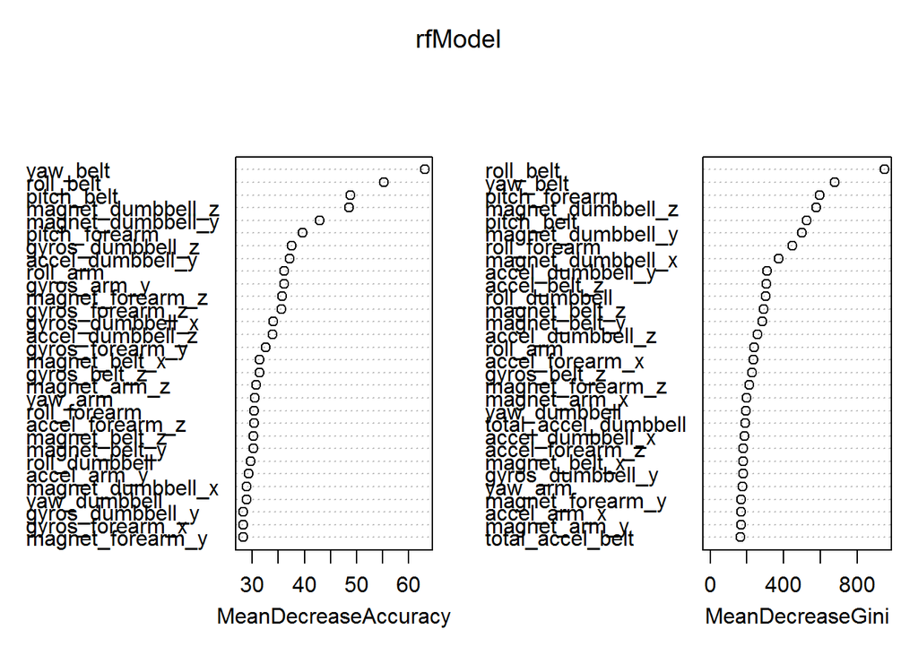

The following is the plot of the model error:

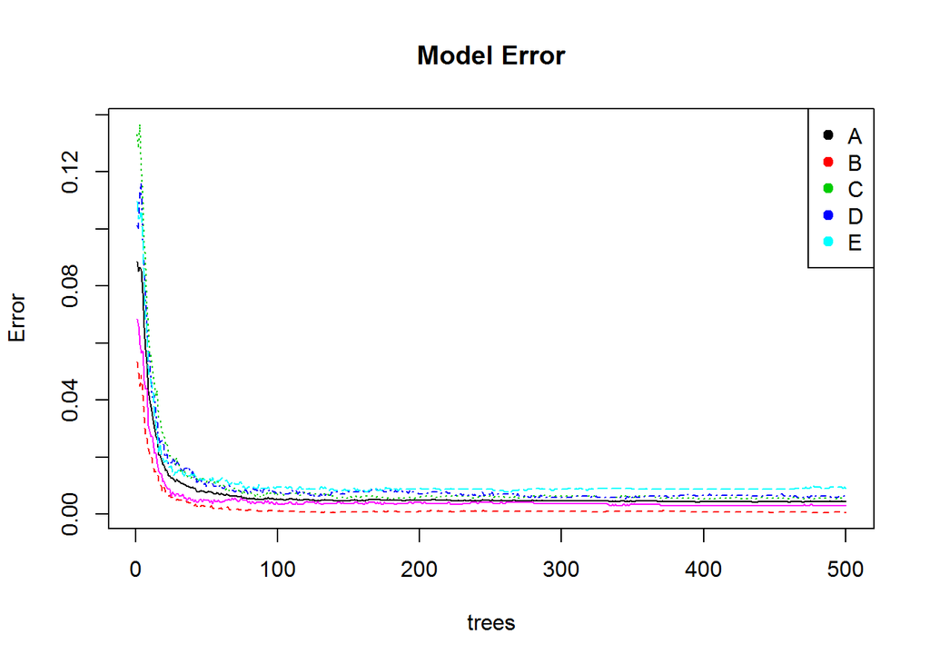

The following is the plot of the model outliners:

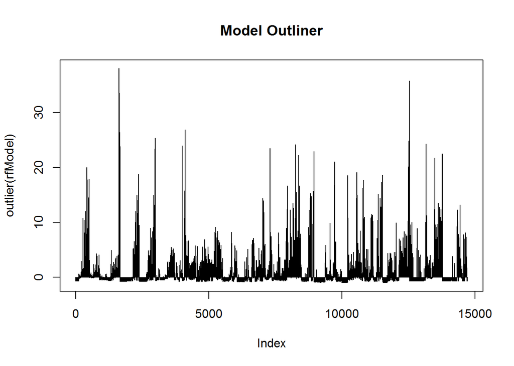

# Appendix - 20 Test Cases

The final 20 test cases were evaluated using the following code:

```r
# final predictions
rfModel <- randomForest(classe ~ ., data = training)
prediction <- predict(rfModel, testingRaw)
```